# Ford GoBike System Data

## by Mostafa Helmy

## Investigation Overview

> The aim of this project is to provide a graphical summary of important features of a data set that includes information about individual rides made in a bike-sharing system by Ford covering the greater San Francisco Bay area.

## Dataset Overview

> The Dataset consists of about 175 thousand entries and 16 features which are: Duaration, Start and End Stations' IDs and Names and Locations, Bike ID, User Type, Gender, and Birth Date. The dataset is consisted of mainly of categorical data and all nominal, except for the Duaration.

## Dataset Features

> I'm most interested in finding out what features are best for predicting the customers subscription status in the dataset

> I believe that the Duaration of the rides will affect the users subscription ths most, I am also considering other features like Start and End stations names, Member Gender, and Member Birth Year

## Duration Distribution

> The most spent duration is concentrated in the period under 1000 seconds

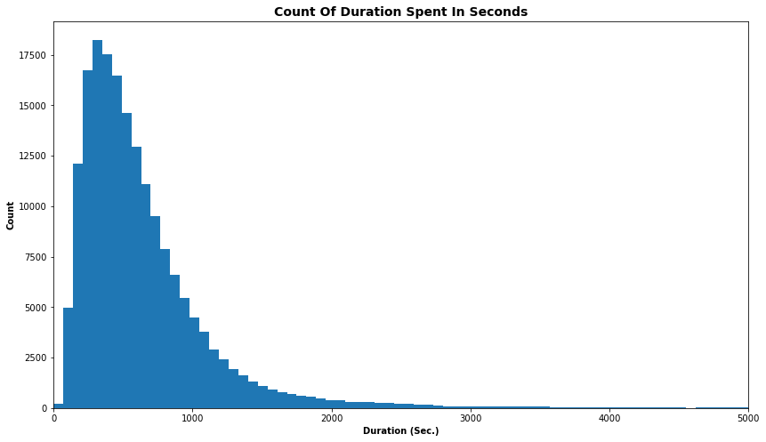

## Most Common Start Stations

> Top Three are: Market St, San Francisco Caltrain Station 2, and Berry St

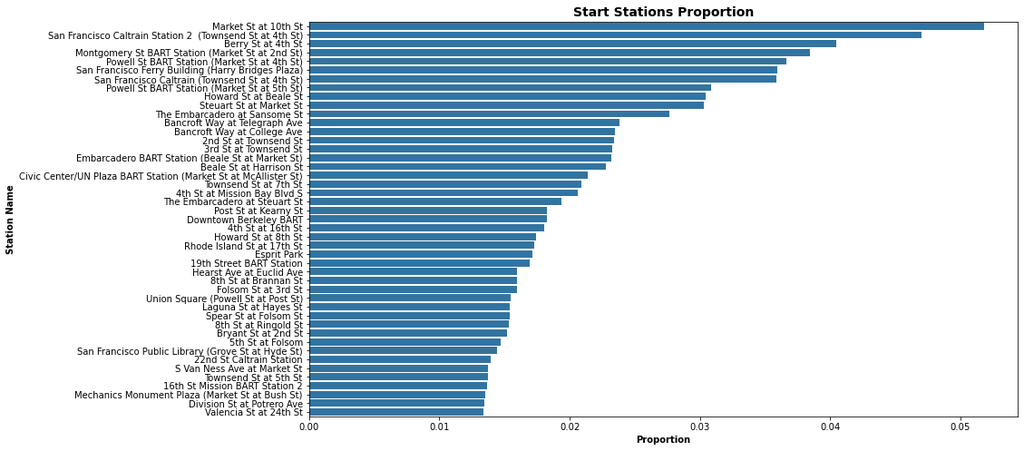

## Most Common End Stations

> Top Three are: San Francisco Caltrain Station 2, Market St, and Montgomery St BART

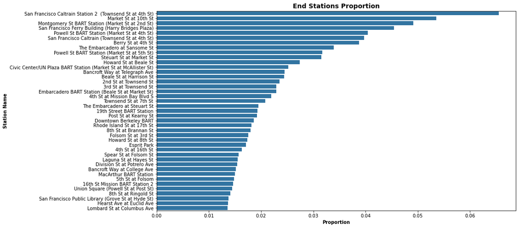

## Most Common Birth Years

> The range with the most concentrated number of users is in the years between 1980s and 1990s

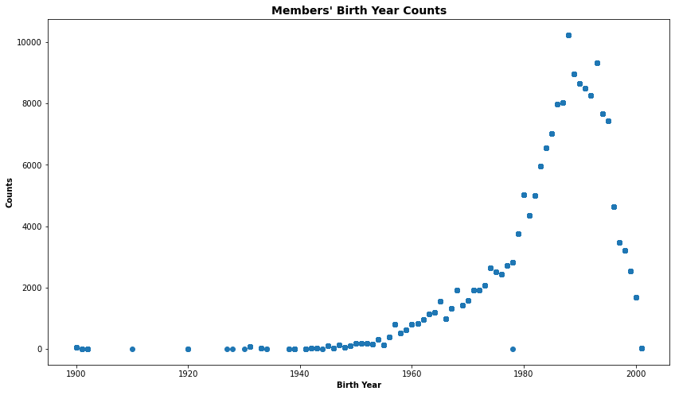

## Members Gender and Subscription Status

> Subscribers numbers are always higher, specially with males the proportion is very large

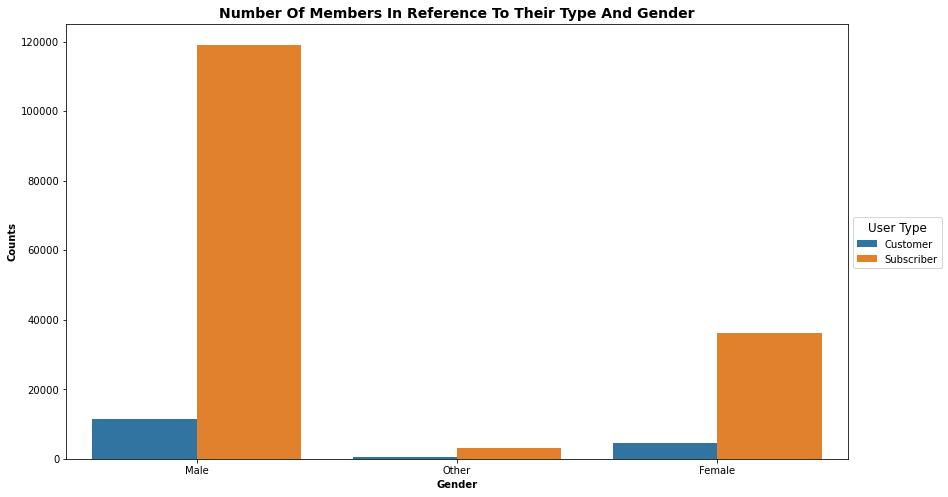

## Start Station Duration by Birth Year

> The most common birth years that spend more duration time is in the range between 1990 and 2000. The most frequent stations are: Bancroft Way at College Ave, Bancroft Way at Telegraph Ave, and Hearst Ave at Euclid Ave

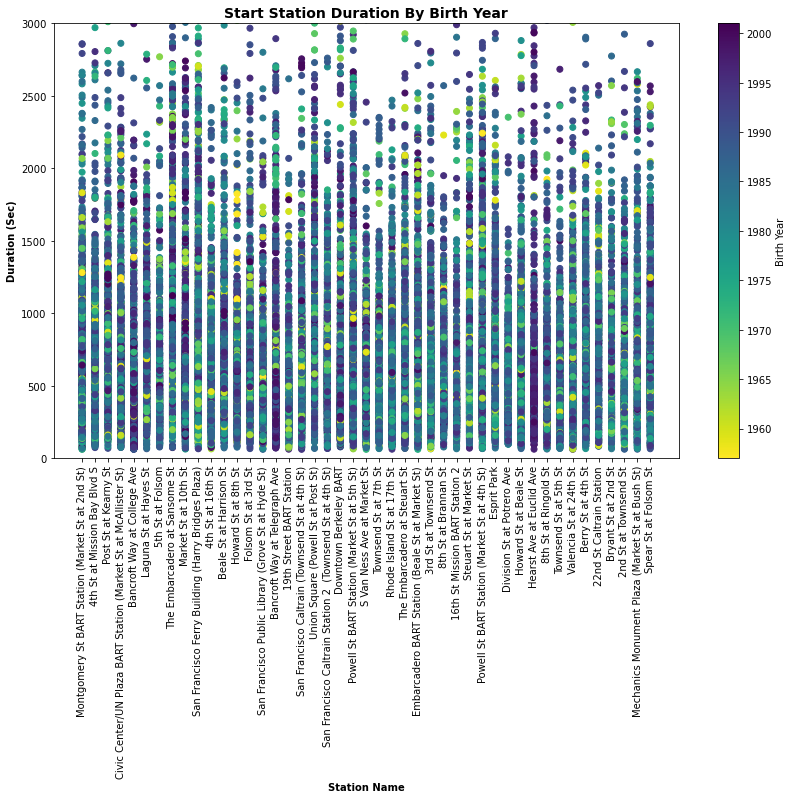

## End Station Duration by Birth Year

> The most common birth years that spend more duration time is in the range between 1990 and 2000. What is interesting, that we can see common frequent stations with the start stations which are: Bancroft Way at College Ave, and Bancroft Way at Telegraph Ave. Hearst Ave at Euclid Ave was also a frequent end station.

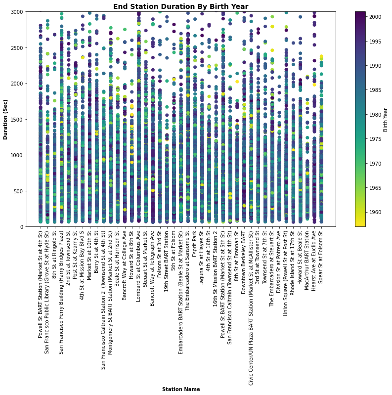